# VDAB Search voor TAI

David D’Haese

Gepubliceerd op 2021-01-30

## Doel

Zoekopdracht op [VDAB](https://www.vdab.be/) om te onderzoek wat de huidige vraag is naar een TAI profiel. Je kan zulke cijfers zeer gemakkelijk manipuleren, net daarom wensen we in volle transparantie laten zien hoe we aan de cijfers rond VDAB vacatures zijn geraakt zodat iedereen zelf kan oordelenn.

## Methode

### Zoektermen

De zoekopdracht is als volgt:

```
AI OR artificieel OR data NOT "data officer" NOT boekhouder NOT commerci* NOT financieel NOT vertegenwoordiger NOT marketing NOT installateur NOT wetenschappen NOT Logistiek NOT Aankoper NOT "onderzoek en ontwikkeling"
```

### filter

In eerste instantie wordt er een filtering doorgevoerd op volgende beroepscategorieën (≠ vacature titel):

- Analist ontwikkelaar ICT (468)
- Bedrijfsanalist ICT (225)
- Administratief medewerker (161)
- Netwerkbeheerder (143)
- Integratie en implementatie expert ICT (140)
- Databankbeheerder (123)
- Verantwoordelijke ICT (77)

De cijfers tussen haakjes geven telkens het aantal resultaten per beroepscategorie weer

In tweede instantie zal er gefilterd worden op Bachelor diploma[^1].

Na bovenstaande filtering werden de zoekresultaten gekopieerd van de VDAB site. Wegens tijdgebrek is er geen tijd voor het goedgekeurd krijgen van toegang tot de API van de VDAB, dus deze actie is voorlopig manueel uitgevoerd. Na het kopiëren werden alle kruisverwijzingen (in de trend van *vacature wordt ook aangeboden door …*) verwijderd. Daarna werden elke derde lijn geselecteerd (regex `(^.*?$[\n]){3}`) en werden telkens de twee daaropvolgende lijnen achteraan toegevoegd, gescheiden van een tabulatie-teken. Tenslotten werden het bedrijf en de locatie gescheiden in afzonderlijke velden (" in " → TAB) alsook de datum in afzonderlijke velden geplaatst.

## Resultaten

### Categorieën en Domeinen

Uitgevoerd op 2021-01-28 om 14:00 gaf de zoekopdracht, ongefilterd 3000+ resultaten. Na het doorvoeren van de boeroepscategorie filter liep dit cijfer terug tot 1197. Niet alle deze gefilterde resultaten zijn relevant voor het Bachelor diploma.

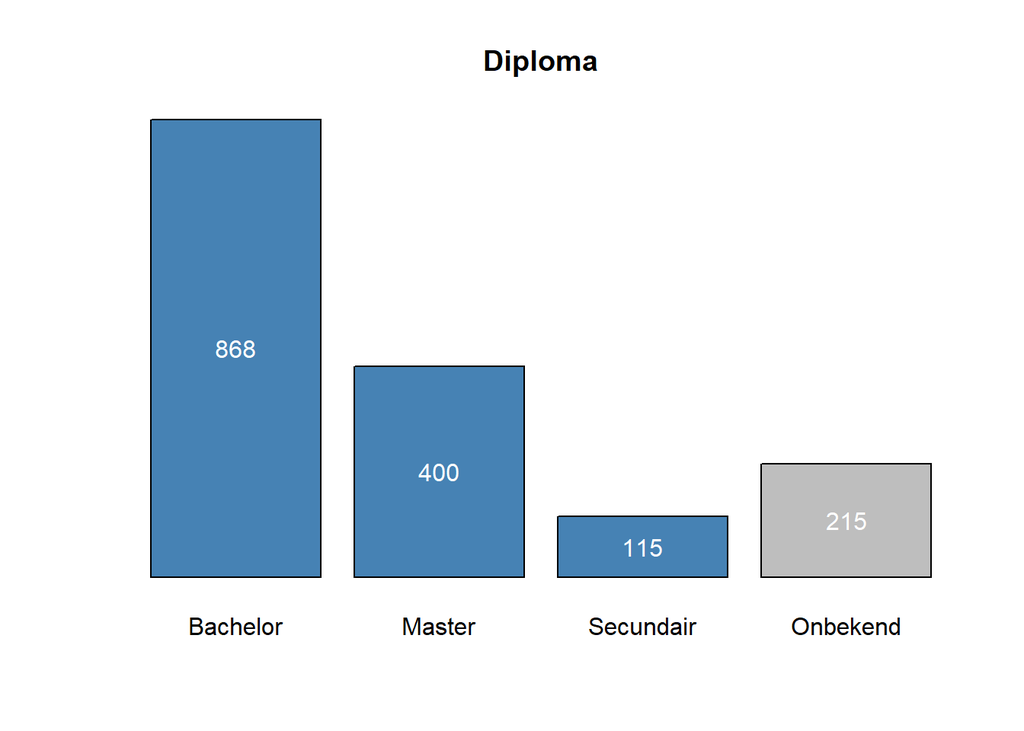

```r
plot_freq <- function(x, title) {
  pos <- x[, barplot(Aantal, names.arg = Category,
      col = c(1, 1, 1, 3),
      main = title, yaxt = "n")]
  x[, text(pos, Aantal / 2, Aantal, col = "white")] %>% invisible
}

fread(
"Category   Aantal
  Bachelor  868
  Master    400
  Secundair 115
  Onbekend  215
  ") %>% plot_freq("Diploma")
```

Enkel de vacatures voor Bachelor diploma’s worden weerhouden. Binnen deze groep kunnen we onderzoeken binnen welk domein de vacatures zich bevinden:

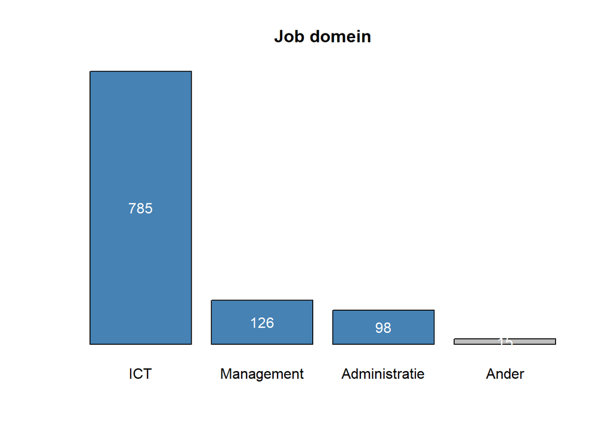

```r
pos <- fread(
"Category   Aantal
ICT 785
Management  126
Administratie   98
Ander   15") %>% plot_freq("Job domein")
```

### Vacature Details

Na het verwerken worden de vacature in een lijst geplaatst waarvan hieronder 25 willekeurige rijen worden getoond:

```r
vdab <- "input.txt" %>% fread(encoding = "UTF-8")
vdab[sample(1:.N, 25)] %>% (kableExtra::kable)
```

| Position | Company | Location | Type | Date_Online | Date_Change |
| --- | --- | --- | --- | --- | --- |
| DATA ANALYST | Hays Brugge | BRUGGE | Vaste Job | 6 januari 2021 | 6 januari 2021 |
| Management Assistant FR/ANG | UNIQUE | BRUSSEL | Interim met optie “vast werk” | 18 januari 2021 | 18 januari 2021 |
| Java Developer | FOREACH | MECHELEN | Vaste Job | 4 april 2019 | 30 december 2020 |
| Innoverende analist - .NET software developer | VIND! ICT | IEPER | Vaste Job | 17 november 2020 | 17 november 2020 |
| Operations Engineer | SKYLINE COMMUNICATIONS | IZEGEM | Vaste Job | 19 januari 2021 | 19 januari 2021 |
| Order Administrator | METISELECT | ZAVENTEM | Tijdelijke job (met optie vast) | 8 december 2020 | 8 december 2020 |
| Noël Franklin bvba - Software Engineer | StepStone | HARELBEKE | Vaste Job | 8 januari 2021 | 22 januari 2021 |
| Ervaren system engineer | LGA IT | GENT | Vaste Job | 6 januari 2021 | 6 januari 2021 |
| Business Analyst | TALENTUS | IEPER | Interim met optie “vast werk” | 29 december 2020 | 29 december 2020 |
| SGS Group Belgium - .Net Developer | StepStone | ANTWERPEN | Vaste Job | 8 december 2020 | 8 december 2020 |
| Data Lake Analyst | COLRUYT GROUP | HALLE | Vaste Job | 3 oktober 2019 | 3 oktober 2019 |
| Junior Java developer | VIND! ICT | WIELSBEKE | Vaste Job | 24 januari 2021 | 24 januari 2021 |
| Customer Support Engineer | ictjob.be | GENT | Vaste Job | 11 januari 2021 | 11 januari 2021 |
| Business and Development Controller met management ambities | Recrewtment | WILRIJK | Vaste Job | 4 januari 2021 | 4 januari 2021 |
| Christelijke Mutualiteiten - Data Warehouse Engineer (SAP Business Objects) | ictjob.be | SCHAARBEEK | Vaste Job | 3 maart 2020 | 14 januari 2021 |
| Software Architectuur & DevOps Professional | Cipal Schaubroeck Geel | GEEL | Tijdelijke job (met optie vast) | 27 januari 2021 | 27 januari 2021 |
| Account advisor privé leasing (tijdelijk) (m/v/x) | ITZU JOBS | DIEGEM | Interim met optie “vast werk” | 26 januari 2021 |  |
| PCM Applicatie Verantwoordelijke | AGO Jobs&HR | WEVELGEM | Vaste Job | 18 januari 2021 | 18 januari 2021 |
| Actemium - Angular Developer - Aalter | StepStone | AALTER | Vaste Job | 6 januari 2021 | 27 januari 2021 |
| SGS Group Belgium - Master Sciences - Clinical Data Manager | StepStone | MECHELEN | Vaste Job | 14 januari 2021 | 26 januari 2021 |
| Cronos International - Information Architect Specialised Data Protection | ictjob.be | BRUSSEL | Vaste Job | 27 januari 2021 | 27 januari 2021 |
| Full Stack Cloud Software Engineer | HARMONEY | GENT | Vaste Job | 16 januari 2021 | 16 januari 2021 |
| Test analist | Cipal Schaubroeck Geel | ZANDHOVEN | Vaste Job | 15 december 2020 | 15 december 2020 |
| Application Analyst/Developer | CLEAR SKY SELECTION | Regio Boom-Aartselaar | Vaste Job | 3 september 2020 | 24 november 2020 |
| BI Tester | Smals | BRUSSEL | Vaste Job | 30 november 2020 | 21 december 2020 |

```r
# Opkuis
vdab[Location == "Regio Antwerpen", Location := "ANTWERPEN"]
vdab[, Location := Location %>% toupper]
```

### Vacature Locatie

Op basis van de BelgiumMaps.StatBel data werd onderstaande kaart gecreëerd. Kleuring en legende werden achteraf manueel aangepast (tweede figuur) omdat dit nogal moeizaam is via de `tmap::qtm` functie en omdat logaritmische cijfers vaak moeilijker interpreteerbaar zijn.

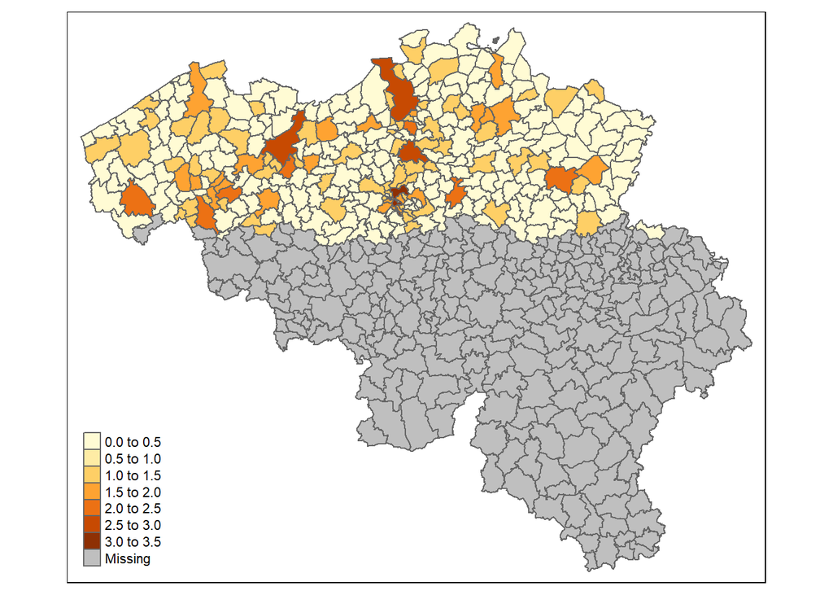

```r
library(BelgiumMaps.StatBel)
library(sf)
library(tmap)

data(BE_ADMIN_MUNTY)
munip_map <- st_as_sf(BE_ADMIN_MUNTY)
munip_map$TX_MUNTY_DESCR_NL <- munip_map$TX_MUNTY_DESCR_NL %>% toupper
munip_data <- vdab[, .N, Location][order(-N)]

vdab_loc <- merge(munip_map, munip_data,
  by.x = "TX_MUNTY_DESCR_NL",
  by.y = "Location", all.x = TRUE, )

vdab_loc$N <- ifelse(
  vdab_loc$TX_RGN_DESCR_NL == "Waals Gewest", NA,
  ifelse(is.na(vdab_loc$N), 0, 1 + log10(vdab_loc$N)))

qtm(vdab_loc, fill = "N", fill.title = "")
```

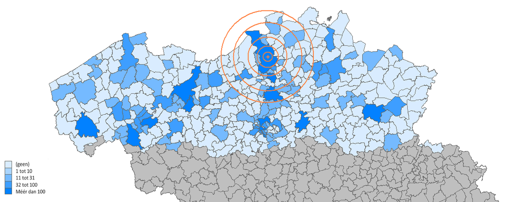

Map showing AI-related jobs

```r
verh_prov_antw <-
  ((vdab_loc %>% as.data.table)[
    TX_PROV_DESCR_NL == "Provincie Antwerpen", sum(N)]) /
  ((vdab_loc %>% as.data.table)[,sum(N, na.rm = TRUE)])
```

Uit de data blijkt dat 24.79% van de vacatures bevinden zich in provincie Antwerpen.

### Lijst van bedrijven in het Antwerpse

```r
merge(munip_map, vdab,
  by.x = "TX_MUNTY_DESCR_NL",
  by.y = "Location") %>%
  as.data.table %>%
  extract(TX_PROV_DESCR_NL == "Provincie Antwerpen", Company) %>%
  unique %>% sort %>% paste0(collapse = "\n") %>% cat
```

```
## 2WORK
## 3-it
## Ackinas
## Actief Interim Mechelen
## AGFA-GEVAERT N.V.
## Amadys
## AUTO1 Group
## Badenoch & Clark
## Bleckmann België N.V.
## Bright Plus
## Brunel
## C-CLEAR PARTNERS
## CEGEKA
## Cipal Schaubroeck Geel
## CONNECT HUMAN CAPITAL
## CONTEC
## CRAX IT
## Ctac België
## DAOUST INTERIM
## Deltalink
## DIGIPOLIS
## Dover Fueling Solutions
## DPD (Belgium) NV/SA
## ELMOS EXPERT
## Experis Belgium
## FAROS
## First
## FLEXSO
## FOREACH
## GZA Ziekenhuizen
## HAVENBEDRIJF ANTWERPEN
## Hays Antwerpen
## ictjob.be
## IFACTO BUSINESS SOLUTIONS
## INTIX
## ISTORM IT
## JOB TALENT
## Jobat
## KOHERA
## MANPOWER GEEL
```

[output cut: 35 more lines]

```
## Trixxo jobs Aarschot
## UniPartners IT - Financial - Engineering Services
## UNIQUE
## UNIQUE KIK
## Universiteit Antwerpen
## Uptime Group
## USG Professionals
## Van Genechten Packaging ( Imas NV )
## VanRoey.be
## vind! Engineering Gent
## Vivaldis Interim
## Whoohoo Belgium
## WIT-GELE KRUIS VAN ANTWERPEN
## Xplore Group
## Xtra Construct
```

### Lijst vacature-titels

Door de wildgroei aan titels in vacatures is het moeilijk om door het bos de bomen te zien en op wetenschappelijk accurate uitspraken te doen. Wat wel kan is een eenvoudige netwerk analyse waarbij het de associatie van de termen uit de vacatures in kaart worden gebracht. We kunnen de aanpak samenvatten als volgt:

- Selecteer alle opgekuiste termen die betrekking hebben op de inhoud (erg veel bedrijfsnamen sluipen door in de vacature omschrijving)
- Breng verwante termen onder dezelfde noemer
- Groepeer de termen volgens de domeinen

Het resultaat kan niet rechtstreeks in dit PDF document getoond worden omdat het om een interactief krachtnetwerk gaat dat enkel in HTML goed weergegeven kan worden (zie interactieve versie [hier](https://ddhaese.github.io/Project_AI_Jobs/vdab.html)).

```r
posit <- vdab[, .N, Position][order(Position)]
posit_repl <- fread("posit_replace.tsv", sep = "\t")
posit_excl <- fread("posit_exclude.tsv", sep = "\t")
posit_grps <- fread("posit_groups.tsv", sep = "\t")

normalize <- function(x) {
  x_min <- min(x, na.rm = TRUE)
  x_max <- max(x, na.rm = TRUE)

  (x - x_min) / (x_max - x_min)
}

library(tm)
library(stringr)
library(quanteda)

posit_dfm <- posit$Position %>%
  toupper %>%
  gsub("-", " ", .) %>%
  gsub("[^A-Z ]", "", .) %>%
  stripWhitespace %>%
  trimws %>%
  tokens(remove_punct = TRUE, remove_numbers = TRUE, remove_symbols = TRUE) %>%
  tokens_remove(posit_excl$To_Delete, padding = TRUE) %>%
  tokens_remove(min_nchar = 2, padding = TRUE) %>%
  tokens_replace(posit_repl$From, posit_repl$To, valuetype = "fixed") %>%
  as.list %>%
  lapply(paste, collapse = " ") %>%
  trimws %>%
  dfm(tolower = FALSE) %>%
  dfm_trim(min_termfreq = 3, min_docfreq = 2)

stopifnot(posit_dfm@Dim[2] < 500)

posit_cooc <- t(posit_dfm) %*% posit_dfm %>% as.matrix
posit_dist <- posit_cooc %>% normalize %>% add(-1) %>% abs

dist_to_net <- function(x, groups = rep("A", nrow(x)),
  group_colors = c("A" = "steelblue"), node_sizes = rep(1, nrow(x)),
  aggr = max, legend = TRUE, fontsize = 14, charge = -400) {

  library(networkD3)
  library(htmlwidgets)
  library(assertthat)

  stopifnot(are_equal(colnames(x), rownames(x)))

  x_nodes <- data.table(NodeID = colnames(x), Group = groups,
    Nodesize = node_sizes)

  x_links <- data.table(
      Source = c(col(x) - 1),
      Target = c(row(x) - 1),
      Dist = c(x))

  x_links[, Combination := c(.SD$Source, .SD$Target) %>%
      sort %>% paste0(collapse = "_"), 1:nrow(x_links)]

  x_links <- x_links[, .(Source = Source[1], Target = Target[1],
    Dist = aggr(Dist)), Combination]

  x_links[, Combination := NULL]
  x_links <- x_links[Dist < 1]

  color_scale <- paste0(
    "d3.scaleOrdinal().domain([\"",
    groups %>% unique %>% sort %>% paste0(collapse = "\", \""),
    "\"]).range([\"",
    group_colors[groups %>% unique %>% sort] %>% unname %>%
      paste0(collapse = "\", \""), "\"]);")

  force_network <- forceNetwork(
    height = 600,
    width = 900,
    Links = x_links,
    Nodes = x_nodes,
    Source = "Source",,
    Target = "Target",
    NodeID = "NodeID",
    Group = "Group",
    Nodesize = "Nodesize",
    bounded = TRUE,
    opacityNoHover = .8,
    linkColour = "#E0E0E0",
    zoom = TRUE,
    colourScale = JS(color_scale),
    legend = legend,
    fontFamily = "Calibri",
    fontSize = fontsize,
    charge = charge,
    opacity = 1,
    linkDistance=JS('function(d) {', 'return d.linkdist;', '}'))

  force_network$x$links$linkdist <- x_links$Dist
  force_network
}

groups <-  rep("OTHER", nrow(posit_dist))
groups[which(colnames(posit_dist) %in% posit_grps$Term)] <-
  posit_grps$Group

group_colors <- c(
  "BUSINESS" = "purple",
  "COMMON" = "grey",
  "DATA" = "orange",
  "IOT" = "steelblue",
  "OTHER" = "lightgrey",
  "SECURITY" = "red",
  "SOFTWARE" = "green"
  )

posit_dist %>%
  dist_to_net(groups = groups, group_colors = group_colors)
```

[interactive chart not shown]

[^1]: de VDAB vacatures maakt voorlopig geen onderscheid tussen academische en professionele bachelors